# Practice with dplyr and ggplot2

Adam Nur

DATA 2401

## Fancy Histograms!

We’ll start by making some histograms.

```r
#install.packages("dslabs")
library(dslabs)
data(heights)
glimpse(heights)
```

```
## Rows: 1,050
## Columns: 2
## $ sex    <fct> Male, Male, Male, Male, Male, Female, Female, Female, Female, M…
## $ height <dbl> 75, 70, 68, 74, 61, 65, 66, 62, 66, 67, 72, 72, 69, 68, 69, 66,…
```

This data is the heights of humans, divided by their biological sex.

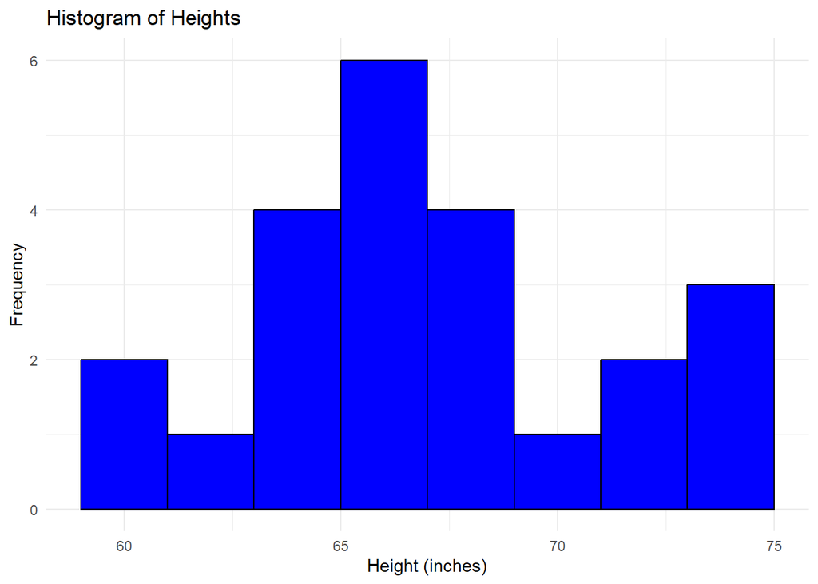

```r
library(ggplot2)
data <- data.frame(
  sex = factor(c("Male", "Male", "Male", "Male", "Male",
                 "Female", "Female", "Female", "Female", "Female",
                 "Male", "Male", "Male", "Male", "Male",
                 "Male", "Female", "Male", "Female", "Female",
                 "Male", "Female", "Female")),
  height = c(75, 70, 68, 74, 61,
             65, 66, 62, 66, 67,
             72, 72, 69, 68, 69,
             66, 75, 64, 60, 67,
             66, 64, 65)
)

ggplot(data, aes(x = height)) +
  geom_histogram(binwidth = 2, fill = "blue", color = "black") +
  labs(title = "Histogram of Heights",
       x = "Height (inches)",
       y = "Frequency") +
  theme_minimal()
```

Change up the binwidth and see how the plots change. Try 1, 5, 10, and 20

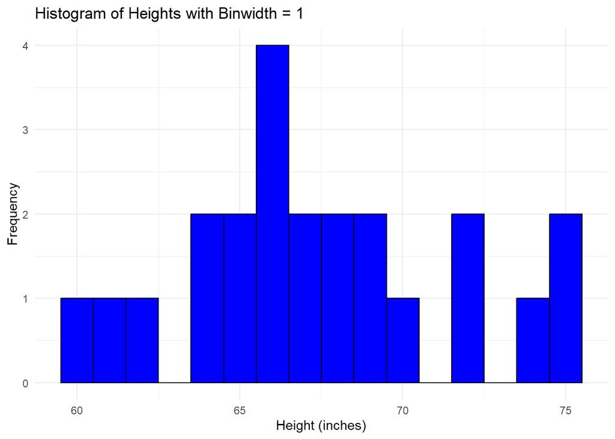

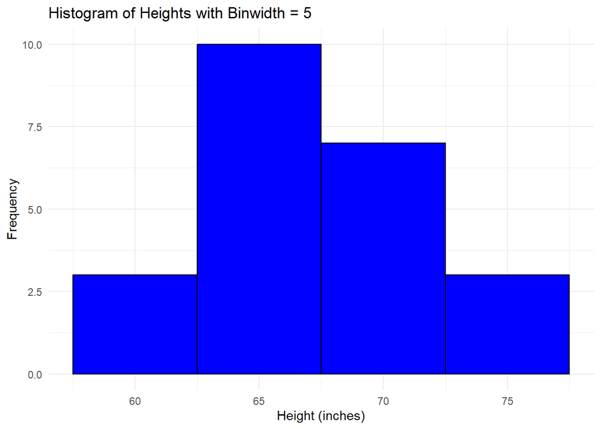

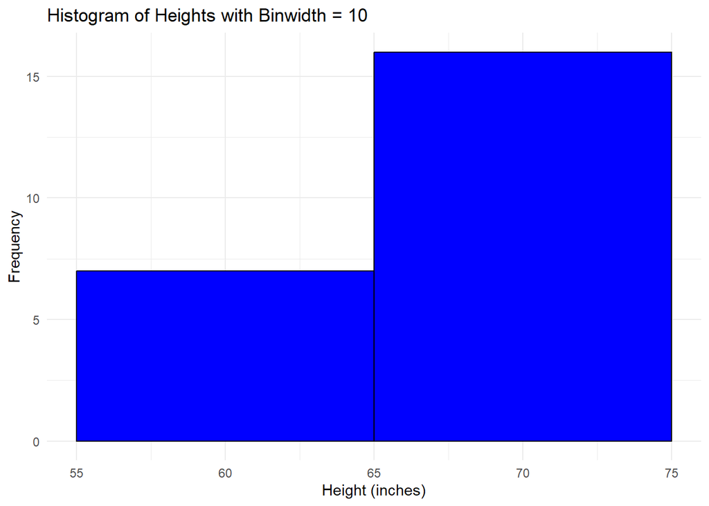

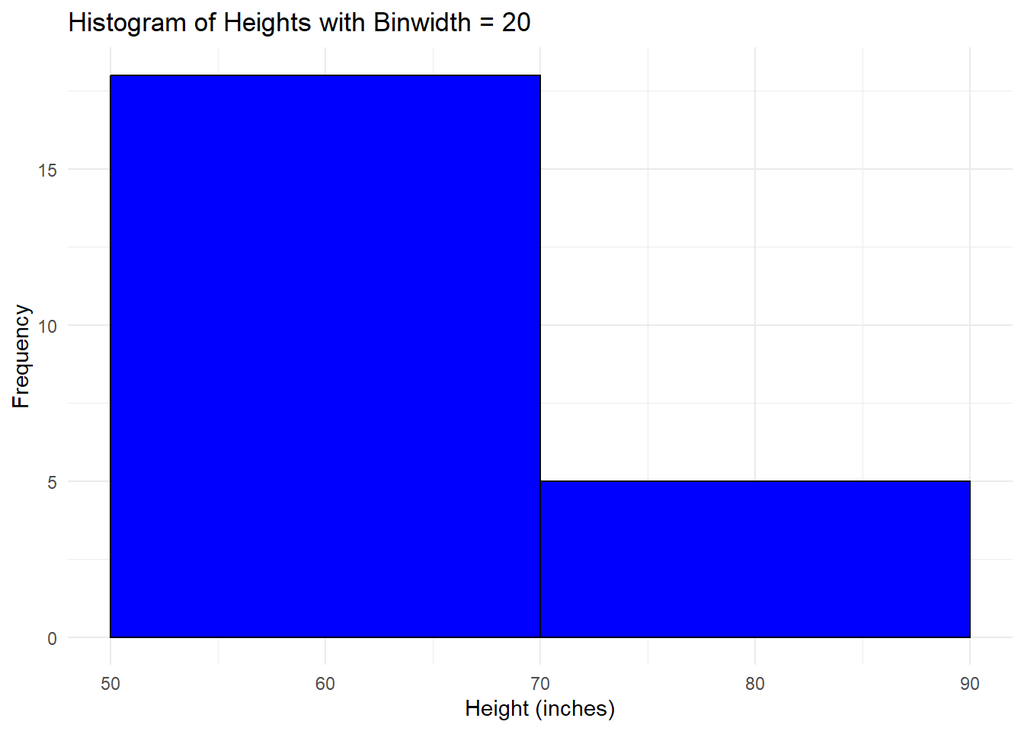

```r
for (bin in c(1, 5, 10, 20))
  print(
    ggplot(data, aes(x = height)) +
      geom_histogram(binwidth = bin, fill = "blue", color = "black") +
      labs(title = paste("Histogram of Heights with Binwidth =", bin),
           x = "Height (inches)", # Fixed the missing closing quotation mark
           y = "Frequency") +
      theme_minimal()
  )
```

Smooth this out to an emperical density with `geom_density()`

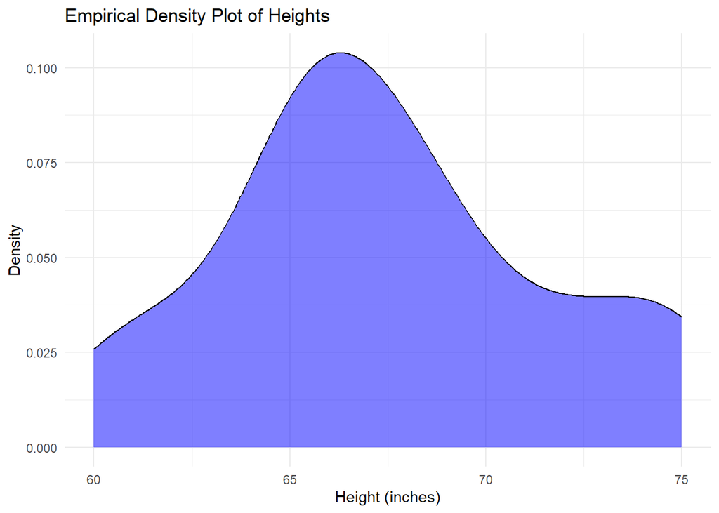

```r
ggplot(data, aes(x = height)) +
  geom_density(fill = "blue", alpha = 0.5) +
  labs(title = "Empirical Density Plot of Heights",
       x = "Height (inches)",
       y = "Density") +
  theme_minimal()
```

Use a new argument in the `aes()`, `group =` to split this density by sex

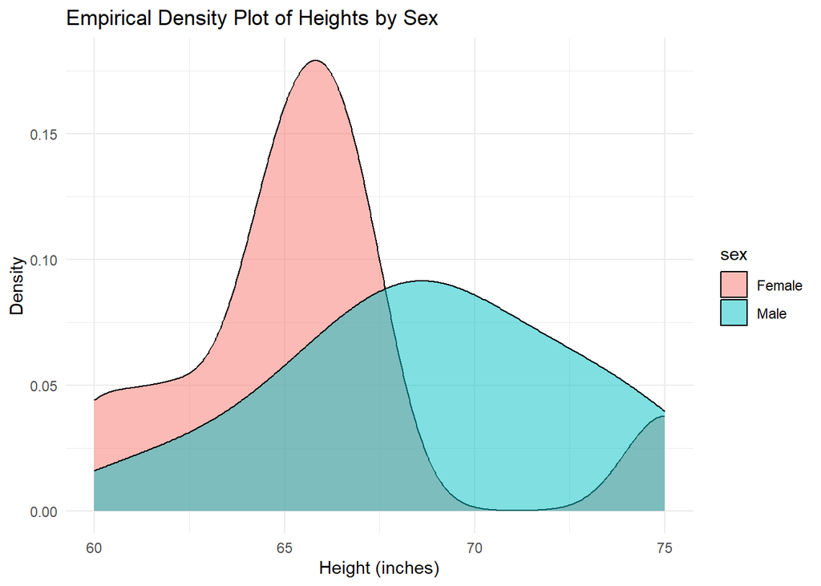

```r
ggplot(data, aes(x = height, group = sex, fill = sex)) +
  geom_density(alpha = 0.5) +
  labs(title = "Empirical Density Plot of Heights by Sex",
       x = "Height (inches)",
       y = "Density") +
  theme_minimal()
```

OR we can do it with `color` or `fill.` If you say you want to color by sex, R knows that you want a different curve for each of them.

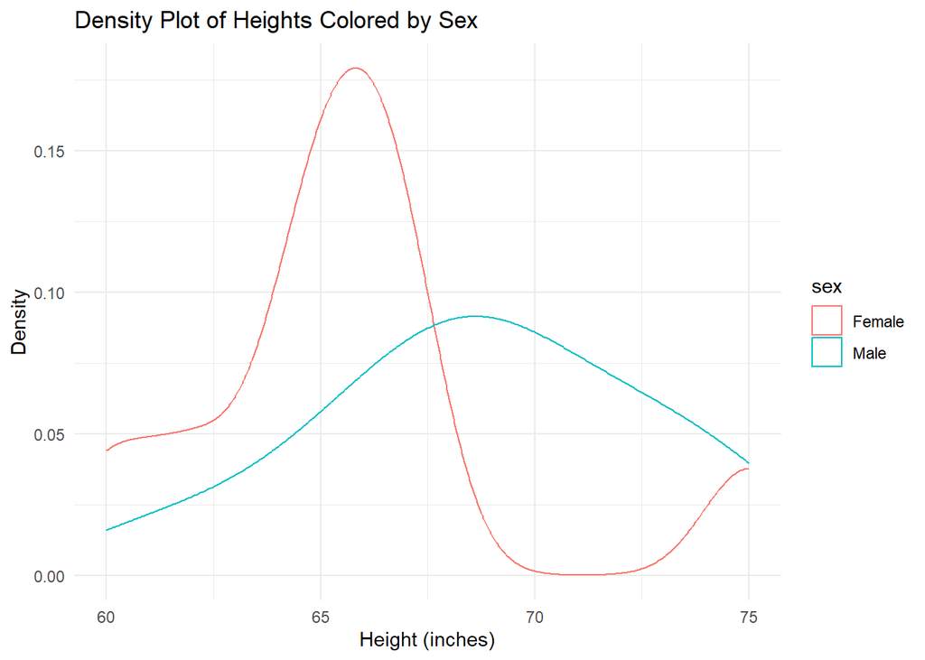

```r
ggplot(data, aes(x = height, color = sex)) +
  geom_density() +
  labs(title = "Density Plot of Heights Colored by Sex",
       x = "Height (inches)",
       y = "Density") +
  theme_minimal()
```

If you’ve used fill, then there is now a slight issue that they are overlapped. We can fix this with alpha transparency!

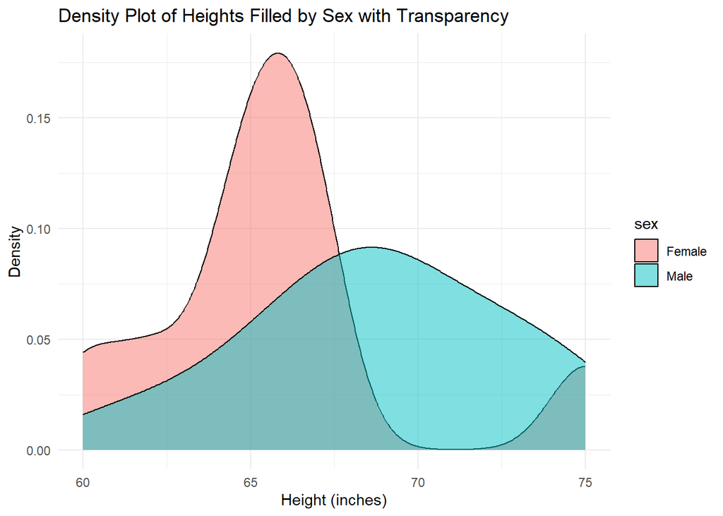

```r
ggplot(data, aes(x = height, fill = sex)) +
  geom_density(alpha = 0.5) + # Alpha transparency set to 0.5
  labs(title = "Density Plot of Heights Filled by Sex with Transparency",
       x = "Height (inches)",
       y = "Density") +
  theme_minimal()
```

Let’s make some boxplots of the same information.

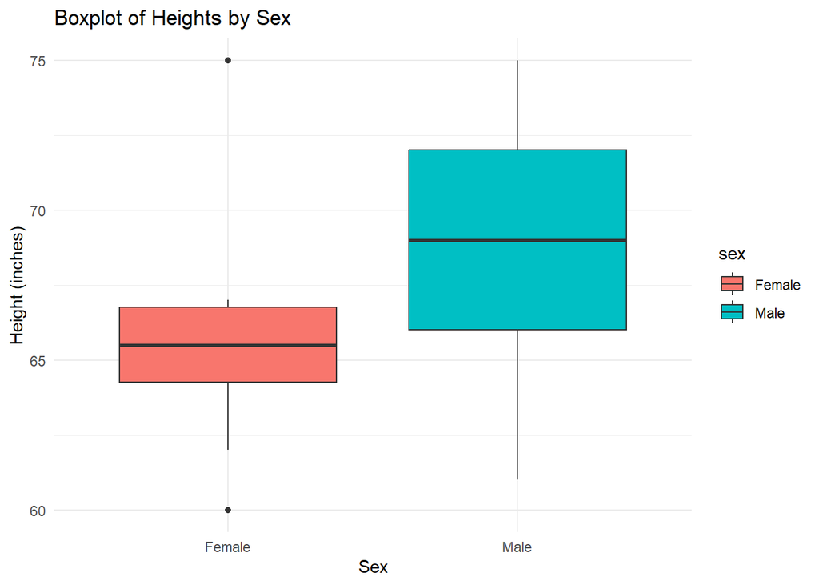

```r
ggplot(data, aes(x = sex, y = height, fill = sex)) +
  geom_boxplot() +
  labs(title = "Boxplot of Heights by Sex",
       x = "Sex",
       y = "Height (inches)") +
  theme_minimal()
```

## Quantatitive summaries:

Find the mean and median overall.

```r
mean_height <- mean(data$height)
median_height <- median(data$height)

cat("Mean Height:", mean_height, "\n")
```

```
## Mean Height: 67.43478
```

```r
cat("Median Height:", median_height, "\n")
```

```
## Median Height: 67
```

Find the mean and median for both groups.

```r
mean_male <- mean(data$height[data$sex == "Male"])
median_male <- median(data$height[data$sex == "Male"])

mean_female <- mean(data$height[data$sex == "Female"])
median_female <- median(data$height[data$sex == "Female"])

cat("Male - Mean Height:", mean_male, ", Median Height:", median_male, "\n")
```

```
## Male - Mean Height: 68.76923 , Median Height: 69
```

```r
cat("Female - Mean Height:", mean_female, ", Median Height:", median_female, "\n")
```

```
## Female - Mean Height: 65.7 , Median Height: 65.5
```

```r
tallest_woman <- max(data$height[data$sex == "Female"])
```

## Presidental Elections Data

```r
# install.packages("pscl")
library(pscl) # loads in the package that has this data.
## You might need to install this...

# data for presidental elections
votedata <-  presidentialElections
glimpse(votedata)
```

```
## Rows: 1,097
## Columns: 4
## $ state   <chr> "Alabama", "Arizona", "Arkansas", "California", "Colorado", "C…
## $ demVote <dbl> 84.76, 67.03, 86.27, 58.41, 54.81, 47.40, 48.11, 74.49, 91.60,…
## $ year    <int> 1932, 1932, 1932, 1932, 1932, 1932, 1932, 1932, 1932, 1932, 19…
## $ south   <lgl> TRUE, FALSE, TRUE, FALSE, FALSE, FALSE, FALSE, TRUE, TRUE, FAL…
```

Let’s look at the democratic vote by state for 2000. We can’t use `geom_bar` for a bar chart, since we have the category in one variable and the “height” of the bar in another. We need `geom_col()`

Make a bar graph of the democratic vote by state in 2000.

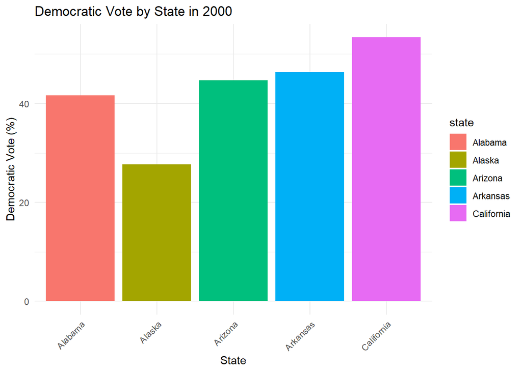

```r
data <- data.frame(
  state = c("Alabama", "Alaska", "Arizona", "Arkansas", "California"),
  democratic_vote = c(41.6, 27.7, 44.7, 46.3, 53.4) # Replace with actual data
)

ggplot(data, aes(x = state, y = democratic_vote, fill = state)) +
  geom_col() +
  labs(title = "Democratic Vote by State in 2000",
       x = "State",
       y = "Democratic Vote (%)") +
  theme_minimal() +
  theme(axis.text.x = element_text(angle = 45, hjust = 1))
```

Well this looks awful. We have two options: swap the x and y or the more fun sounding… Coordinate flip!

Use `coord_flip()` on the previous graph to make it better.

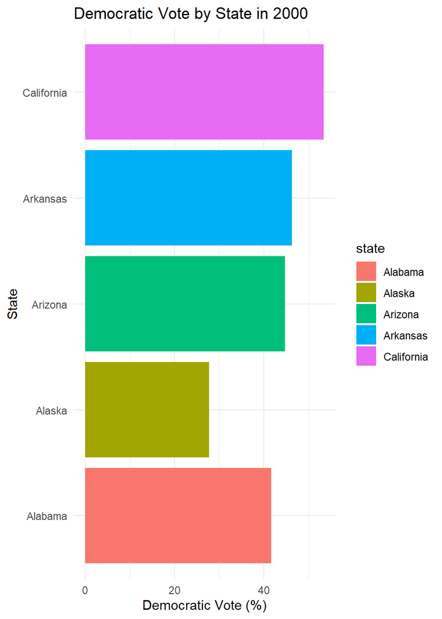

```r
data <- data.frame(
  state = c("Alabama", "Alaska", "Arizona", "Arkansas", "California"),
  democratic_vote = c(41.6, 27.7, 44.7, 46.3, 53.4) # Replace with actual data
)

ggplot(data, aes(x = state, y = democratic_vote, fill = state)) +
  geom_col() +
  coord_flip() + # Flips the axes
  labs(title = "Democratic Vote by State in 2000",
       x = "State",
       y = "Democratic Vote (%)") +
  theme_minimal()
```

I don’t love the squashed together coordinates, but it’s a display window issue.

So. This is a helpful graph, but it would be *more* helpful if it was ordered. Use `x = reorder(x_variable, y_variable)` in `aes()` to order the x variable by the y variable

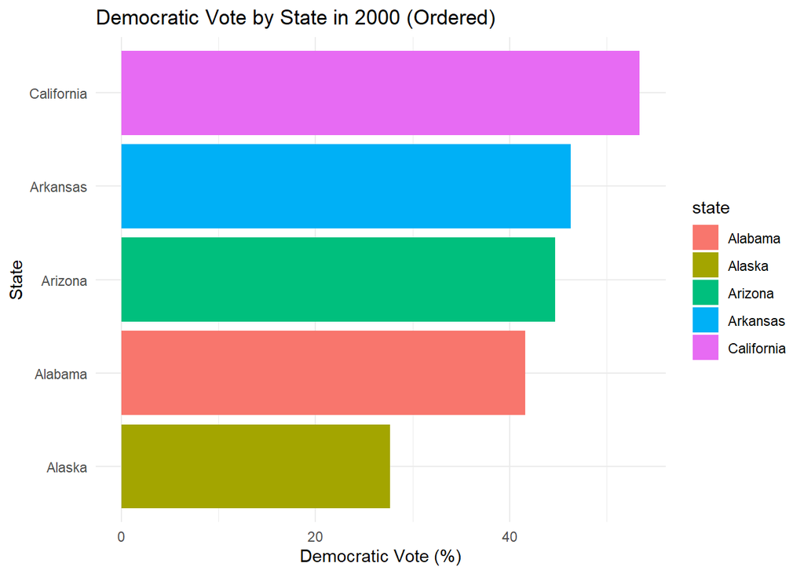

```r
data <- data.frame(
  state = c("Alabama", "Alaska", "Arizona", "Arkansas", "California"),
  democratic_vote = c(41.6, 27.7, 44.7, 46.3, 53.4) # Replace with actual data
)

ggplot(data, aes(x = reorder(state, democratic_vote), y = democratic_vote, fill = state)) +
  geom_col() +
  coord_flip() +
  labs(title = "Democratic Vote by State in 2000 (Ordered)",
       x = "State",
       y = "Democratic Vote (%)") +
  theme_minimal()
```

So, what if I want to see what the north and south states did different?

start with a facet_wrap using the `south` variable:

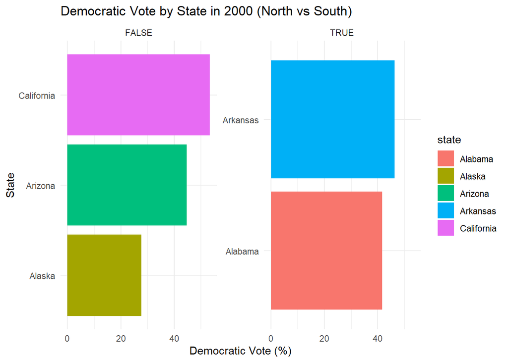

```r
data <- data.frame(
  state = c("Alabama", "Alaska", "Arizona", "Arkansas", "California"),
  democratic_vote = c(41.6, 27.7, 44.7, 46.3, 53.4),
  south = c(TRUE, FALSE, FALSE, TRUE, FALSE)
)

ggplot(data, aes(x = reorder(state, democratic_vote), y = democratic_vote, fill = state)) +
  geom_col() +
  coord_flip() +
  facet_wrap(~south, scales = "free_y") +
  labs(title = "Democratic Vote by State in 2000 (North vs South)",
       x = "State",
       y = "Democratic Vote (%)") +
  theme_minimal()
```

Okay, that’s not great. Lets *color* by south instead.

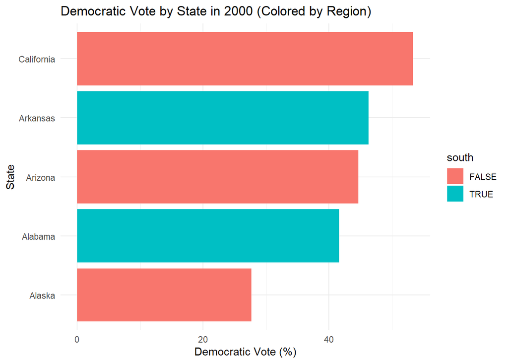

```r
data <- data.frame(
  state = c("Alabama", "Alaska", "Arizona", "Arkansas", "California"),
  democratic_vote = c(41.6, 27.7, 44.7, 46.3, 53.4),
  south = c(TRUE, FALSE, FALSE, TRUE, FALSE)
)

ggplot(data, aes(x = reorder(state, democratic_vote), y = democratic_vote, fill = south)) +
  geom_col() +
  coord_flip() +
  labs(title = "Democratic Vote by State in 2000 (Colored by Region)",
       x = "State",
       y = "Democratic Vote (%)") +
  theme_minimal()
```

I’m a good data scientist, so I want my plot to have a name! and my axes to have lables! Use `labs` to add a title, subtitle, and x and y labels.

```r
data <- data.frame(
  state = c("Alabama", "Alaska", "Arizona", "Arkansas", "California"),
  democratic_vote = c(41.6, 27.7, 44.7, 46.3, 53.4),
  south = c(TRUE, FALSE, FALSE, TRUE, FALSE)
)

ggplot(data, aes(x = reorder(state, democratic_vote), y = democratic_vote, fill = south)) +
  geom_col() +
  coord_flip() +
  labs(
    title = "Democratic Vote by State in 2000",
    subtitle = "Comparing Northern and Southern States",
    x = "State",
    y = "Democratic Vote (%)"
  ) +
  theme_minimal()
```

[output not shown]

You can move the legend with `theme(legend.position = "bottom")`

```r
data <- data.frame(
  state = c("Alabama", "Alaska", "Arizona", "Arkansas", "California"),
  democratic_vote = c(41.6, 27.7, 44.7, 46.3, 53.4),
  south = c(TRUE, FALSE, FALSE, TRUE, FALSE)
)

ggplot(data, aes(x = reorder(state, democratic_vote), y = democratic_vote, fill = south)) +
  geom_col() +
  coord_flip() +
  labs(
    title = "Democratic Vote by State in 2000",
    subtitle = "Comparing Northern and Southern States",
    x = "State",
    y = "Democratic Vote (%)"
  ) +
  theme_minimal() +
  theme(legend.position = "bottom")
```

[output not shown]

```r
data <- data.frame(
  state = c("Alabama", "Alaska", "Arizona", "Arkansas", "California",
            "Alabama", "Alaska", "Arizona", "Arkansas", "California"),
  year = c(2008, 2008, 2008, 2008, 2008, 2016, 2016, 2016, 2016, 2016),
  democratic_vote = c(39.9, 38.8, 45.1, 42.5, 61.0,
                      34.4, 36.6, 44.6, 37.5, 62.0)
)

data$year <- as.numeric(data$year)

filtered_data <- data %>%
  filter(year %in% c(2008, 2016))
```

We need to know who won! We could add a vertical line at 50 for who got more, to indicate the majority of votes. Adding the layer `geom_hline()` adds a horizontal line. (What do you guess `geom_vline()` would do?)

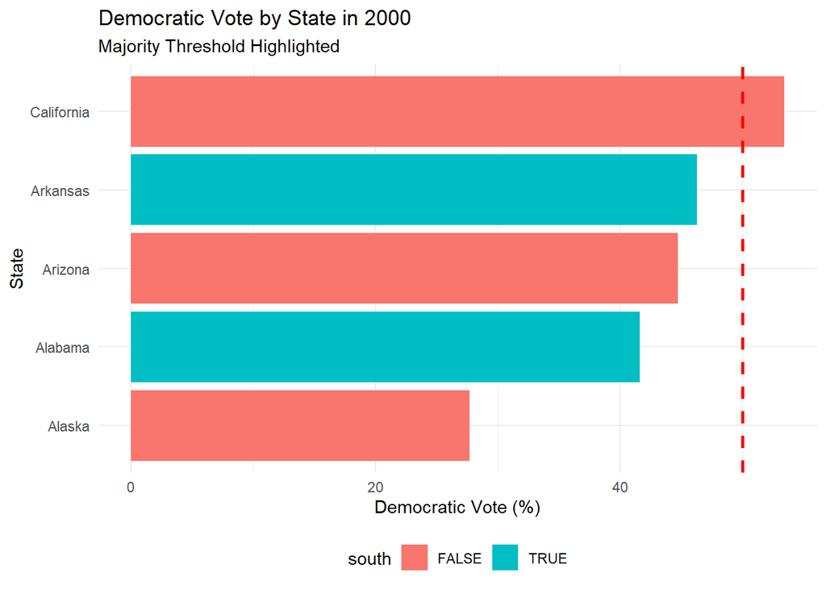

```r
data <- data.frame(
  state = c("Alabama", "Alaska", "Arizona", "Arkansas", "California"),
  democratic_vote = c(41.6, 27.7, 44.7, 46.3, 53.4),
  south = c(TRUE, FALSE, FALSE, TRUE, FALSE)
)

ggplot(data, aes(x = reorder(state, democratic_vote), y = democratic_vote, fill = south)) +
  geom_col() +
  coord_flip() +
  geom_hline(yintercept = 50, linetype = "dashed", color = "red", size = 1) +
  labs(
    title = "Democratic Vote by State in 2000",
    subtitle = "Majority Threshold Highlighted",
    x = "State",
    y = "Democratic Vote (%)"
  ) +
  theme_minimal() +
  theme(legend.position = "bottom")
```

### Getting fancy with a map!

When using geom_polygon or geom_map, you will typically need two data frames:

- one contains the coordinates of each polygon (positions)
- the other the values associated with each polygon (values).

An id variable links the two together.

Run the below code to get a map graph.

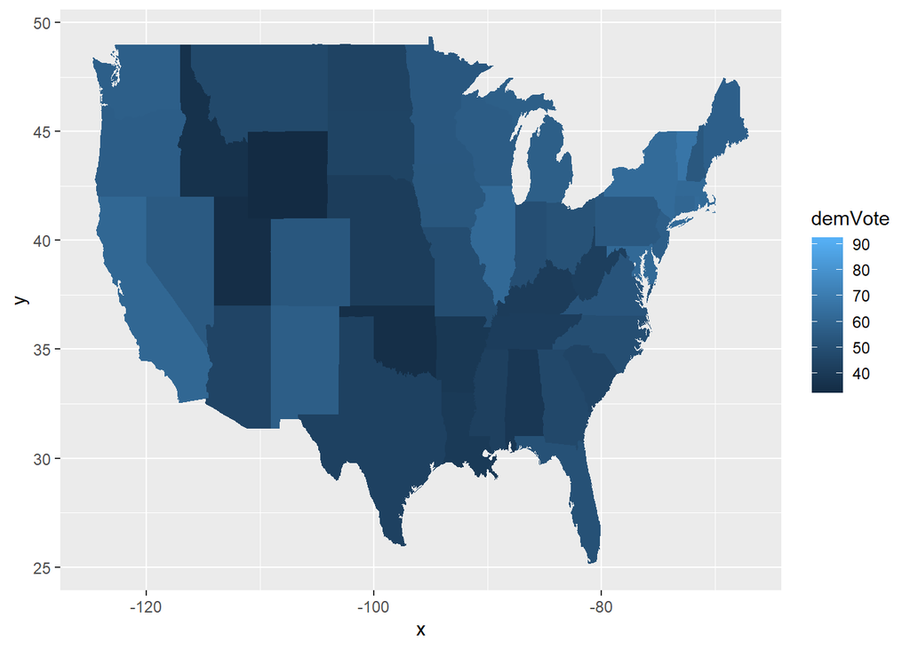

```r
library(maps)
votedata$state <- tolower(votedata$state)  ## states need to be lowercase for linking

states_map <- map_data("state") ## this gives us the lat and long for each point of each state.

map_plot <-  ggplot(data =  votedata %>% filter(year == 2008), aes(map_id = state)) +
    geom_map(aes(fill = demVote), map = states_map) +
    expand_limits(x = states_map$long, y = states_map$lat)
map_plot
```

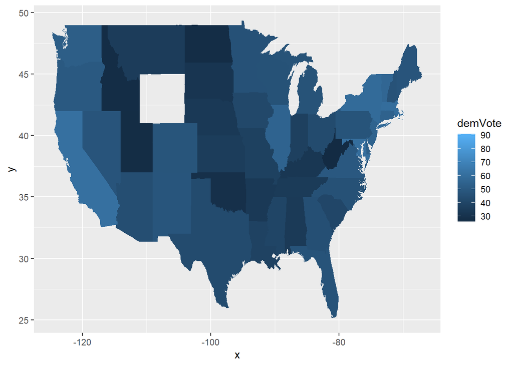

```r
map_plot <-  ggplot(data =  votedata %>% filter(year == 2016), aes(map_id = state)) +
  geom_map(aes(fill = demVote), map = states_map)+
  expand_limits(x = states_map$long, y = states_map$lat)
map_plot
```

```r
data <- data.frame(
  state = tolower(c("Alabama", "Alaska", "Arizona", "Arkansas", "California")),
  south = c(TRUE, FALSE, FALSE, TRUE, FALSE)
)

map_data <- map_data("state")

merged_data <- map_data %>%
  left_join(data, by = c("region" = "state"))
```

### Some more dplyr practice

I want to know the average democratic vote for N vs S, by year.

First, find the average democratic votes for the north and the south, every year. You’ll need to do a *double* `group_by()` here. You do it in one call of the function.

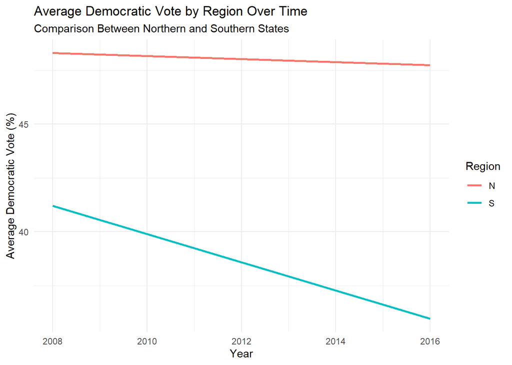

```r
data <- data.frame(
  state = c("Alabama", "Alaska", "Arizona", "Arkansas", "California",
            "Alabama", "Alaska", "Arizona", "Arkansas", "California"),
  year = c(2008, 2008, 2008, 2008, 2008, 2016, 2016, 2016, 2016, 2016),
  democratic_vote = c(39.9, 38.8, 45.1, 42.5, 61.0,
                      34.4, 36.6, 44.6, 37.5, 62.0),
  region = c("S", "N", "N", "S", "N",
             "S", "N", "N", "S", "N")
)

data %>%
  group_by(region, year) %>%
  summarise(average_vote = mean(democratic_vote, na.rm = TRUE)) %>%
  ggplot(aes(x = year, y = average_vote, color = region, group = region)) +
  geom_line(size = 1) +
  labs(
    title = "Average Democratic Vote by Region Over Time",
    subtitle = "Comparison Between Northern and Southern States",
    x = "Year",
    y = "Average Democratic Vote (%)",
    color = "Region"
  ) +
  theme_minimal()
```

## Layering plots!

Penguins!

```r
library(palmerpenguins)
glimpse(penguins)
```

```
## Rows: 344
## Columns: 8
## $ species           <fct> Adelie, Adelie, Adelie, Adelie, Adelie, Adelie, Adel…
## $ island            <fct> Torgersen, Torgersen, Torgersen, Torgersen, Torgerse…
## $ bill_length_mm    <dbl> 39.1, 39.5, 40.3, NA, 36.7, 39.3, 38.9, 39.2, 34.1, …
## $ bill_depth_mm     <dbl> 18.7, 17.4, 18.0, NA, 19.3, 20.6, 17.8, 19.6, 18.1, …
## $ flipper_length_mm <int> 181, 186, 195, NA, 193, 190, 181, 195, 193, 190, 186…
## $ body_mass_g       <int> 3750, 3800, 3250, NA, 3450, 3650, 3625, 4675, 3475, …
## $ sex               <fct> male, female, female, NA, female, male, female, male…
## $ year              <int> 2007, 2007, 2007, 2007, 2007, 2007, 2007, 2007, 2007…
```

We can use boxplots to visualize the distribution of weight (body_mass_g) within each species:

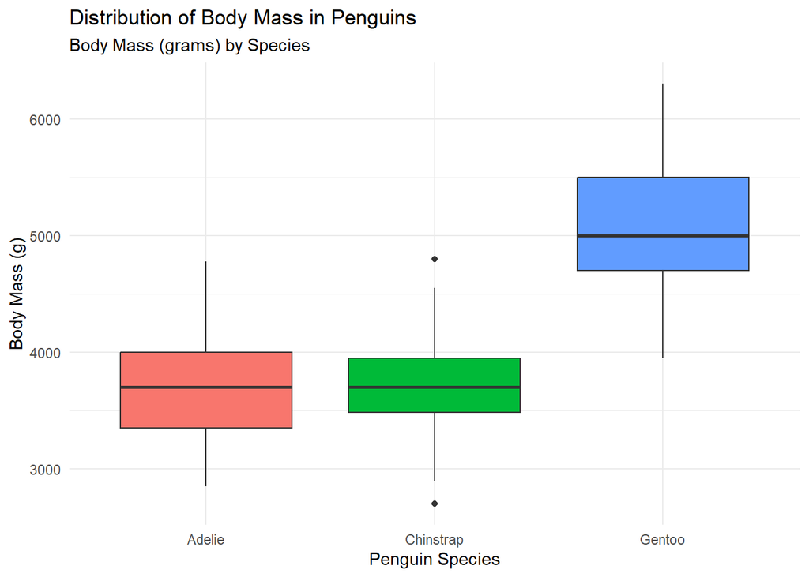

```r
ggplot(penguins, aes(x = species, y = body_mass_g, fill = species)) +
  geom_boxplot() +
  labs(
    title = "Distribution of Body Mass in Penguins",
    subtitle = "Body Mass (grams) by Species",
    x = "Penguin Species",
    y = "Body Mass (g)"
  ) +
  theme_minimal() +
  theme(legend.position = "none")
```

What if we also want the points? Layering!! Add a geom_point to your existing boxplot. geom_boxplot + geom_point!

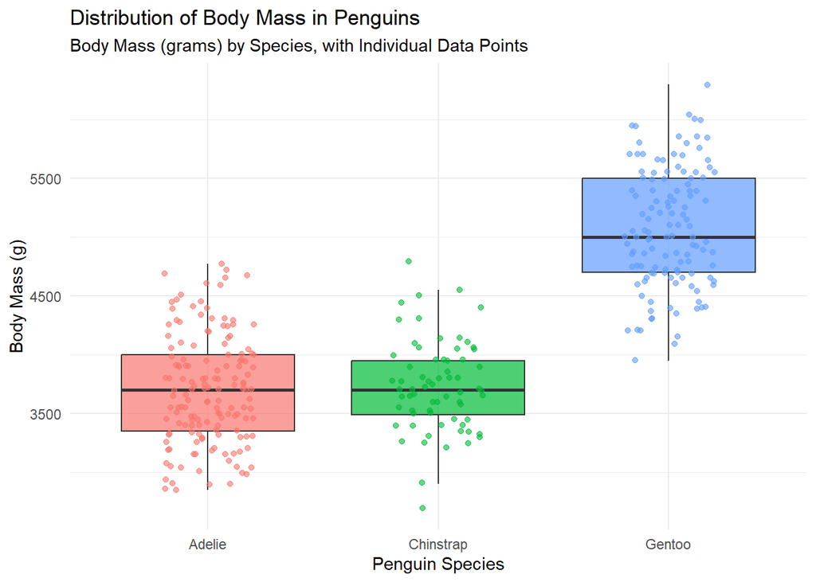

```r
ggplot(penguins, aes(x = species, y = body_mass_g, fill = species)) +
  geom_boxplot(outlier.shape = NA, alpha = 0.7) +
  geom_point(position = position_jitter(width = 0.2), aes(color = species), alpha = 0.6) +

  labs(
    title = "Distribution of Body Mass in Penguins",
    subtitle = "Body Mass (grams) by Species, with Individual Data Points",
    x = "Penguin Species",
    y = "Body Mass (g)"
  ) +
  theme_minimal() +
  theme(legend.position = "none")
```

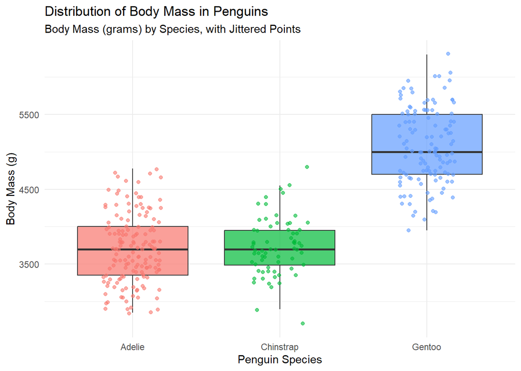

```r
ggplot(penguins, aes(x = species, y = body_mass_g, fill = species)) +
  geom_boxplot(outlier.shape = NA, alpha = 0.7) + # Boxplot without outliers and slightly transparent
  geom_jitter(position = position_jitter(width = 0.2), aes(color = species), alpha = 0.6) + # Jittered points
  labs(
    title = "Distribution of Body Mass in Penguins",
    subtitle = "Body Mass (grams) by Species, with Jittered Points",
    x = "Penguin Species",
    y = "Body Mass (g)"
  ) +
  theme_minimal() +
  theme(legend.position = "none")
```

How to get the boxplots on top? The layers are plotted in the order you give them, so change to geom_point + geom_boxplot. (You might want to change the alpha on the boxplot to be able to see the plots under them)

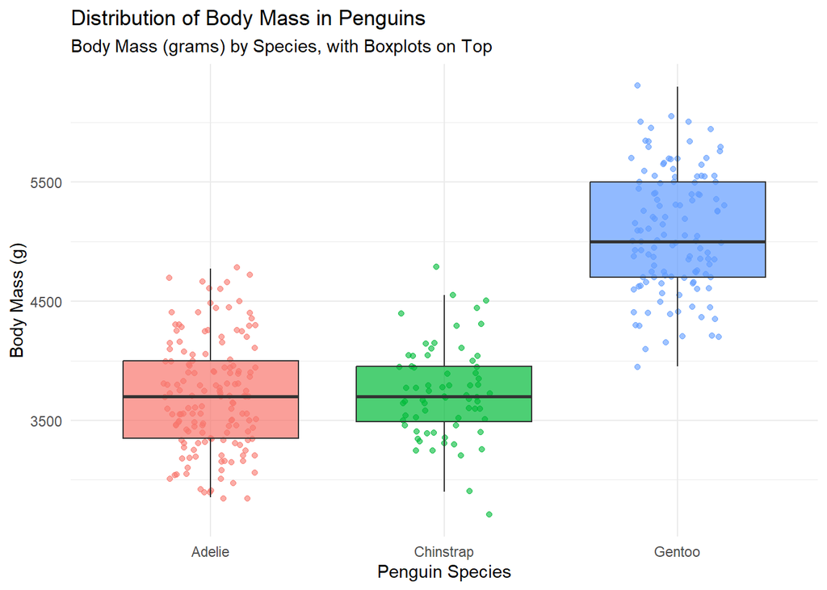

```r
ggplot(penguins, aes(x = species, y = body_mass_g, fill = species)) +
  geom_jitter(position = position_jitter(width = 0.2), aes(color = species), alpha = 0.6) +

  geom_boxplot(outlier.shape = NA, alpha = 0.7) +
  labs(
    title = "Distribution of Body Mass in Penguins",
    subtitle = "Body Mass (grams) by Species, with Boxplots on Top",
    x = "Penguin Species",
    y = "Body Mass (g)"
  ) +
  theme_minimal() +
  theme(legend.position = "none")
```

Maybe let’s try replacing the boxplot with a `geom_violin()`?

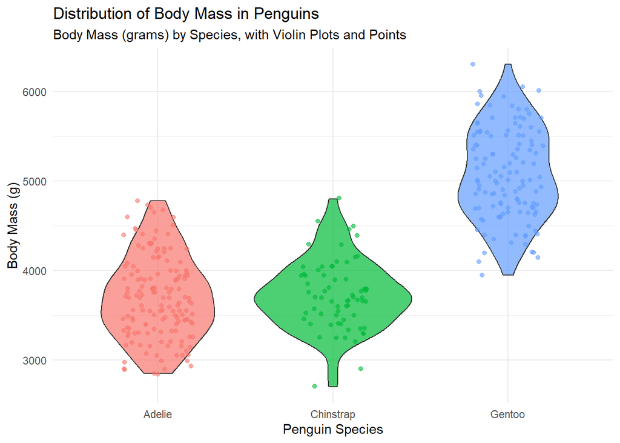

```r
ggplot(penguins, aes(x = species, y = body_mass_g, fill = species)) +
  geom_violin(alpha = 0.7) +
  geom_jitter(position = position_jitter(width = 0.2), aes(color = species), alpha = 0.6) +

  labs(
    title = "Distribution of Body Mass in Penguins",
    subtitle = "Body Mass (grams) by Species, with Violin Plots and Points",
    x = "Penguin Species",
    y = "Body Mass (g)"
  ) +
  theme_minimal() +
  theme(legend.position = "none")
```

## If time: More Practice with Penguins

- Count the number of male and female penguins for each species.
- Find the average penguin mass for each island
- Find the average bill length by sex
- Make a plot of bill_length and bill_depth, but only for the female penguins.
- Make a plot of flipper length and body mass, faceted by island and colored by species.
- Plot the density of the flipper length, colored by sex
- Plot the density of the body mass, colored by year

```r
penguins %>%
  group_by(species, sex) %>%
  summarise(count = n(), .groups = 'drop')
```

```
## # A tibble: 8 × 3
##   species   sex    count
##   <fct>     <fct>  <int>
## 1 Adelie    female    73
## 2 Adelie    male      73
## 3 Adelie    <NA>       6
## 4 Chinstrap female    34
## 5 Chinstrap male      34
## 6 Gentoo    female    58
## 7 Gentoo    male      61
## 8 Gentoo    <NA>       5
```

```r
penguins %>%
  group_by(island) %>%
  summarise(avg_mass = mean(body_mass_g, na.rm = TRUE), .groups = 'drop')
```

```
## # A tibble: 3 × 2
##   island    avg_mass
##   <fct>        <dbl>
## 1 Biscoe       4716.
## 2 Dream        3713.
## 3 Torgersen    3706.
```

```r
penguins %>%
  group_by(sex) %>%
  summarise(avg_bill_length = mean(bill_length_mm, na.rm = TRUE), .groups = 'drop')
```

```
## # A tibble: 3 × 2
##   sex    avg_bill_length
##   <fct>            <dbl>
## 1 female            42.1
## 2 male              45.9
## 3 <NA>              41.3
```

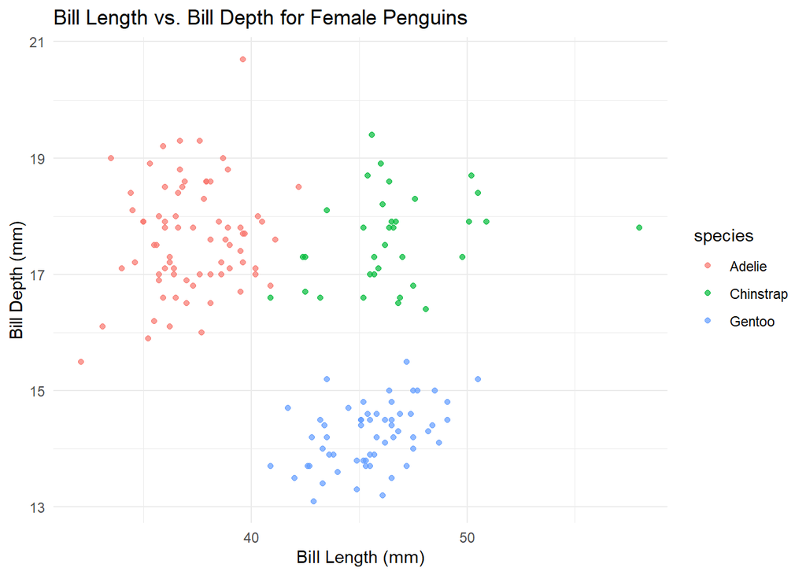

```r
ggplot(penguins %>% filter(sex == "female"), aes(x = bill_length_mm, y = bill_depth_mm, color = species)) +
  geom_point(alpha = 0.7) +
  labs(
    title = "Bill Length vs. Bill Depth for Female Penguins",
    x = "Bill Length (mm)",
    y = "Bill Depth (mm)"
  ) +
  theme_minimal()
```

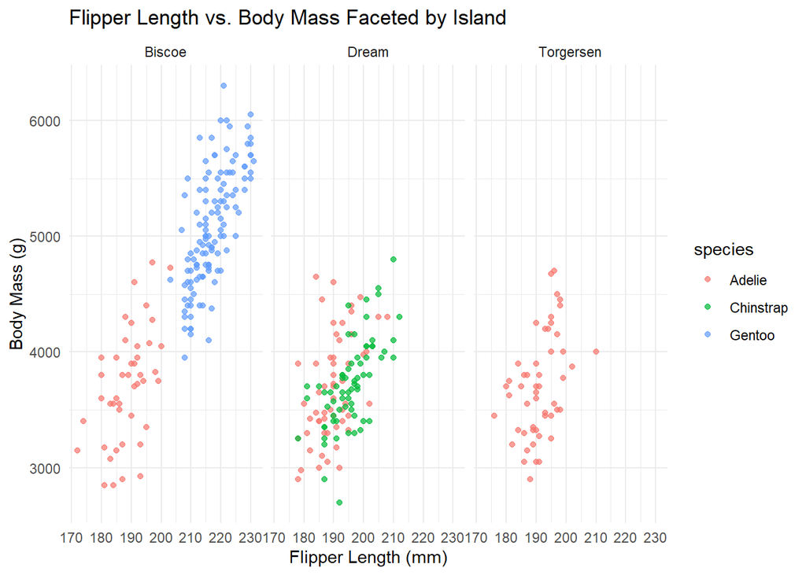

```r
ggplot(penguins, aes(x = flipper_length_mm, y = body_mass_g, color = species)) +
  geom_point(alpha = 0.7) +
  facet_wrap(~island) +
  labs(
    title = "Flipper Length vs. Body Mass Faceted by Island",
    x = "Flipper Length (mm)",
    y = "Body Mass (g)"
  ) +
  theme_minimal()
```

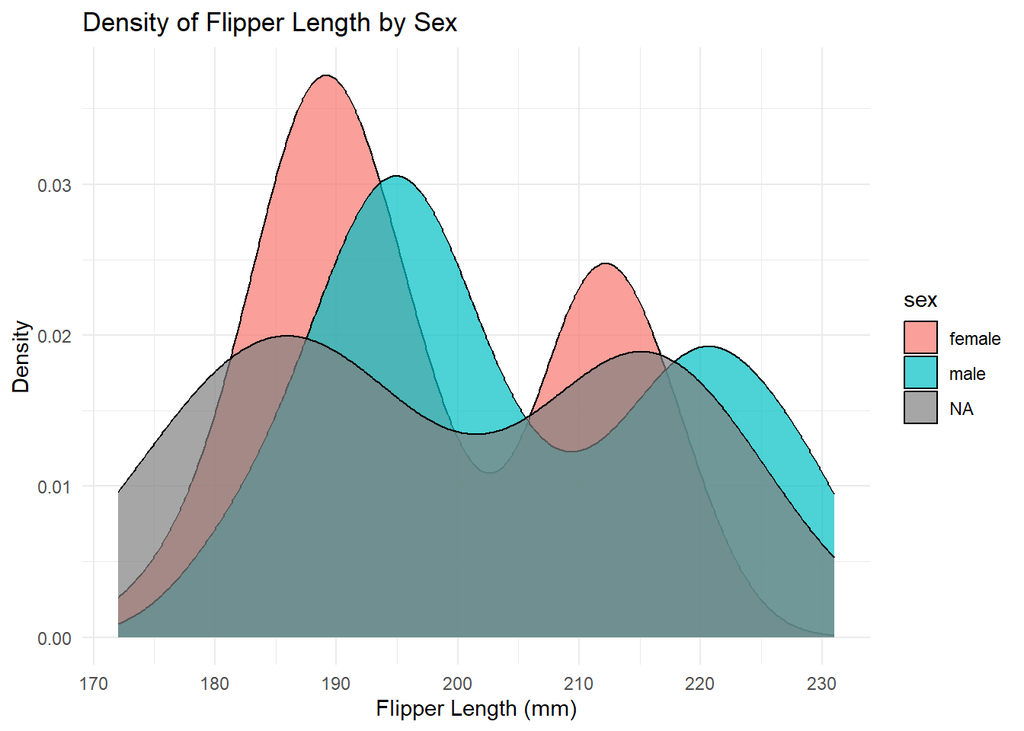

```r
ggplot(penguins, aes(x = flipper_length_mm, fill = sex)) +
  geom_density(alpha = 0.7) +
  labs(
    title = "Density of Flipper Length by Sex",
    x = "Flipper Length (mm)",
    y = "Density"
  ) +
  theme_minimal()
```

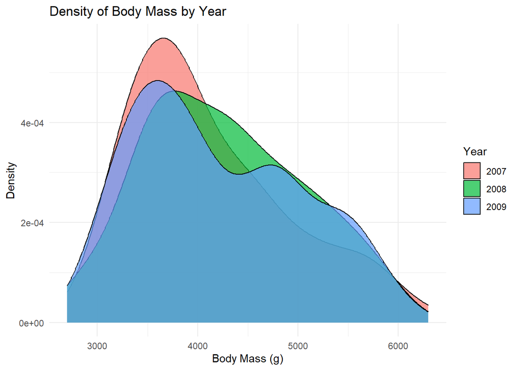

```r
ggplot(penguins, aes(x = body_mass_g, fill = factor(year))) +
  geom_density(alpha = 0.7) +
  labs(
    title = "Density of Body Mass by Year",
    x = "Body Mass (g)",
    y = "Density",
    fill = "Year"
  ) +
  theme_minimal()
```